# Lab 1: LCA Scavenger Hunt

IMMERSE Training Team

Updated: June 04, 2023

[figure not shown]

[figure not shown]

The Institute of Mixture Modeling for Equity-Oriented Researchers, Scholars, and Educators (IMMERSE) is an IES funded training grant (R305B220021) to support education scholars in integrating mixture modeling into their research.

- Please [visit our website](https://immerse.education.ucsb.edu/) to learn more.
- Visit our [GitHub](https://github.com/immerse-ucsb) account to access all the IMMERSE materials.
- Follow us on [Twitter](https://twitter.com/IMMERSE_UCSB)!

How to reference this workshop: Institute of Mixture Modeling for Equity-Oriented Researchers, Scholars, and Educators (2023). IMMERSE In-Person Training Workshop (IES No. 305B220021). Institute of Education Sciences. https://immerse-ucsb.github.io/pre-training

Load packages

```r
library(MplusAutomation)
library(tidyverse) #collection of R packages designed for data science
library(here) #helps with filepaths
library(janitor) #clean_names
library(gt) # creates tables
library(DiagrammeR) # create path diagrams
```

Binary LCA indicators<sup>1</sup>

| Name | Description | Values |
| --- | --- | --- |
| Enjoy | I Enjoy Science | 0 = Disagree, 1 = Agree |
| Useful | Science is Useful in Everyday Problems | 0 = Disagree, 1 = Agree |
| Logical | Science Helps Logical Thinking | 0 = Disagree, 1 = Agree |
| Job | Need Science for a Good Job | 0 = Disagree, 1 = Agree |
| Adult | Will Use Science Often as an Adult | 0 = Disagree, 1 = Agree |

[interactive chart not shown]

The data can be found in the `data` folder and is called `lsay_subset.csv`.

```r
lsay_data <- read_csv(here("lab1","data","lsay_subset.csv")) %>%
  clean_names() # make variable names lowercase

# Quick data summary
summary(lsay_data)
```

```
##       rand              lsayid           region          urban
##  Min.   :0.000071   Min.   :101101   Min.   :1.000   Min.   :1.00
##  1st Qu.:0.264785   1st Qu.:115157   1st Qu.:2.000   1st Qu.:1.00
##  Median :0.510609   Median :128160   Median :2.000   Median :2.00
##  Mean   :0.508064   Mean   :149651   Mean   :2.468   Mean   :2.05
##  3rd Qu.:0.756934   3rd Qu.:142111   3rd Qu.:3.000   3rd Qu.:3.00
##  Max.   :0.999804   Max.   :309224   Max.   :4.000   Max.   :3.00
##
##      gender          mothed          fathed          raceth        math_irt
##  Min.   :1.000   Min.   :1.000   Min.   :1.000   Min.   :1.00   Min.   :26.57
##  1st Qu.:1.000   1st Qu.:2.000   1st Qu.:2.000   1st Qu.:3.00   1st Qu.:50.00
##  Median :2.000   Median :2.000   Median :2.000   Median :3.00   Median :59.30
##  Mean   :1.522   Mean   :2.352   Mean   :2.637   Mean   :2.76   Mean   :58.81
##  3rd Qu.:2.000   3rd Qu.:3.000   3rd Qu.:4.000   3rd Qu.:3.00   3rd Qu.:68.21
##  Max.   :2.000   Max.   :5.000   Max.   :5.000   Max.   :5.00   Max.   :94.19
##                  NA's   :102     NA's   :297     NA's   :158    NA's   :875
##      enjoy             good           undrstnd         nervous
##  Min.   :0.0000   Min.   :0.0000   Min.   :0.0000   Min.   :0.0000
##  1st Qu.:0.0000   1st Qu.:0.0000   1st Qu.:1.0000   1st Qu.:0.0000
##  Median :1.0000   Median :1.0000   Median :1.0000   Median :1.0000
##  Mean   :0.6687   Mean   :0.6929   Mean   :0.7628   Mean   :0.5896
##  3rd Qu.:1.0000   3rd Qu.:1.0000   3rd Qu.:1.0000   3rd Qu.:1.0000
##  Max.   :1.0000   Max.   :1.0000   Max.   :1.0000   Max.   :1.0000
##  NA's   :448      NA's   :446      NA's   :468      NA's   :494
##      scared           useful          logical            job
##  Min.   :0.0000   Min.   :0.0000   Min.   :0.0000   Min.   :0.0000
##  1st Qu.:0.0000   1st Qu.:0.0000   1st Qu.:0.0000   1st Qu.:0.0000
##  Median :1.0000   Median :1.0000   Median :1.0000   Median :1.0000
##  Mean   :0.6869   Mean   :0.6945   Mean   :0.6398   Mean   :0.7428
##  3rd Qu.:1.0000   3rd Qu.:1.0000   3rd Qu.:1.0000   3rd Qu.:1.0000
##  Max.   :1.0000   Max.   :1.0000   Max.   :1.0000   Max.   :1.0000
##  NA's   :465      NA's   :474      NA's   :481      NA's   :495
##      adult
##  Min.   :0.0000
##  1st Qu.:0.0000
##  Median :1.0000
##  Mean   :0.7017
##  3rd Qu.:1.0000
##  Max.   :1.0000
##  NA's   :468
```

1. Using MplusAutomation, estimate a 4-class LCA model using the variable indicators `enjoy`, `useful`, `logical`, `job`, `adult`:

```r
input  <- mplusObject(
  TITLE = "LSAY 4-Class Model - Lab 1",
  VARIABLE = "categorical = enjoy useful logical job adult;
  usevar =  enjoy useful logical job adult;
  classes = c(4);",

  ANALYSIS =
   "estimator = mlr;
    type = mixture;",

  OUTPUT = "tech11 tech14;",

  PLOT = "type = plot3;
    series = enjoy-adult(*);",

  usevariables = colnames(lsay_data),
  rdata = lsay_data)

output <- mplusModeler(input,
                       dataout=here("lab1", "mplus", "lsay.dat"),
                       modelout=here("lab1", "mplus","lsay.inp") ,
                       check=TRUE, run = TRUE, hashfilename = FALSE)
```

After estimating a model using `MplusAutomation` , the first thing we need to do is open up our output. You should make it a habit of always checking your output before moving forward with any code to make tables or figures.

2. Locate the following in the output file [note the line number]:
- Total analysis sample size
- Observed item response counts and proportions
- Number of free parameters
- Log Likelihood Value
- Bayesian Information Criteria (BIC)
- Final class counts and proportions based on the estimated model
- Model-estimated item thresholds for each class
- Latent class multinomial logit means (class proportion/size)
- Class-specific item response probabilities

Sneak peak of the item probability plot:

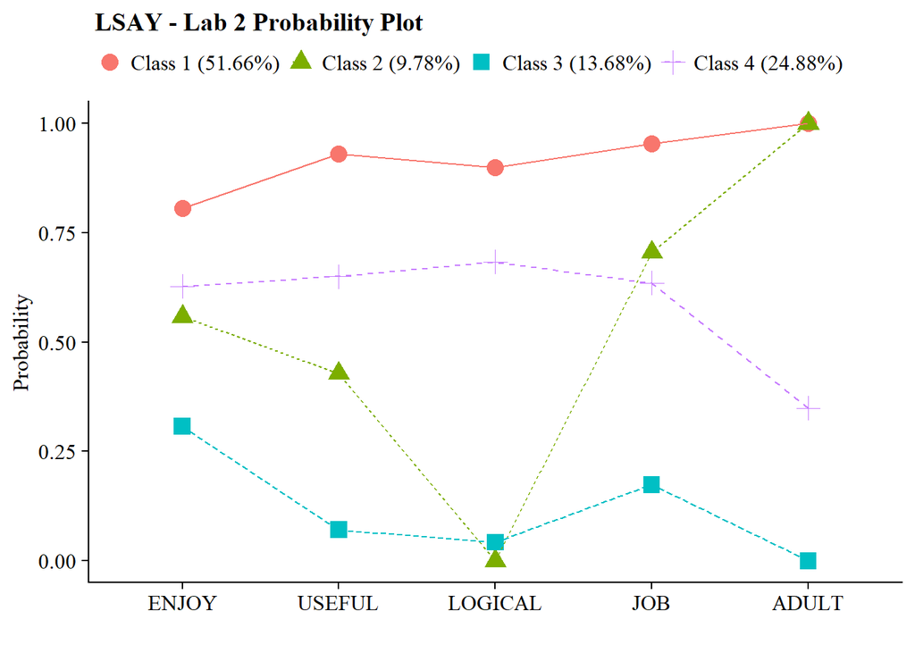

```r
source(here("plot_lca.txt")) # This is a custom function to plot mixtures from the Mplus output

model <- readModels(here("lab1", "mplus", "lsay.out")) # read in output

plot_lca(model_name = model)
```